# Modelling the distribution of biodiversity under global climate change

Jorge Assis, PhD // Nord University, Norway // biodiversityDS, Centre of Marine Sciences, Portugal

## Species occurrence data

## Plotting species occurrence data

Species distribution models require georeferenced records of occurrence (e.g. species locations, which is the response or dependent variable). Such data are widely available in digital format (e.g., online repositories like GBIF).

The first approach to the data is to map the occurrence records to depict the species distribution. This is done by plotting the occurrence records on a map of the study area.

```r
# load libraries
library(terra)
# read occurrence records
records <- read.table("../Data/Text delimited/species_presence_records.csv", sep = ";", header = TRUE)
# transform data.frame into a spatial object
records <- vect(records, geom = c("Lon", "Lat"), crs = "EPSG:4326")
# read a landmass polygon
landmass <- vect("../Data/Vector data/Landmass/landmass.shp")
# crop landmass to the european Extent
mediterraneanExtent <- ext(-35, 45, 25, 55)
landmassMediterranean <- crop(landmass, mediterraneanExtent)
```

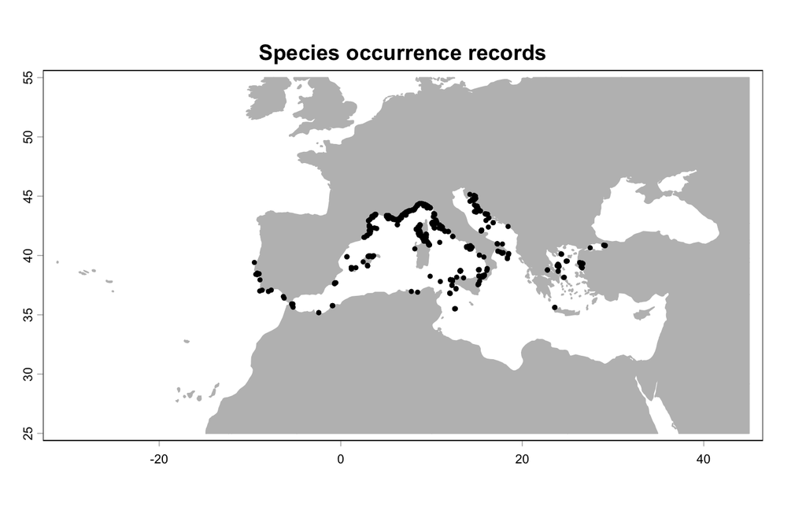

```r
# plot the landmass and the records
plot(landmassMediterranean, main = "Species occurrence records", col = "Gray", border = "Gray",
    axes = TRUE)
plot(records, col = "Black", pch = 19, cex = 0.5, add = TRUE)
```

#### Challenge 3.1

The main objective of this challenge is to **plot** biodiversity records **from a csv file**, for a given **region**.

**Packages, files and functions to accomplish the challenge:**

**Files to use**  
"species_presence_records.csv"  
"landmass.shp"  
**Functions to use**  
library  
read.table  
vect  
ext  
crop  
plot OR ggplot

## Downloading biodiversity records in R

Extracting species records of occurrence from data warehouses such OBIS and GBIF.

### From OBIS

```r
# get data from OBIS
recordsObis <- getExternalDataObis(taxa = "Laminaria ochroleuca", getCitation = TRUE)
# inspect the top records of the data.frame
head(recordsObis)
```

```
## Data downloaded from OBIS
## Taxa:  Laminaria ochroleuca
## Number of records:  1502
```

| scientificName | Lon | Lat | year | month | day |
| --- | --- | --- | --- | --- | --- |
| Laminaria ochroleuca | -3.056564 | 48.83898 | 2017 | 4 | 18 |
| Laminaria ochroleuca | -5.141720 | 48.44537 | 2017 | 4 | 21 |
| Laminaria ochroleuca | -3.951233 | 47.72167 | NA | NA | NA |
| Laminaria ochroleuca | -6.313705 | 49.92338 | NA | NA | NA |
| Laminaria ochroleuca | -6.297950 | 49.97683 | NA | NA | NA |

### From GBIF

```r
# get data from GBIF
recordsGbif <- getExternalDataGbif(taxa = "Laminaria ochroleuca", getCitation = TRUE)
# inspect the top records of the data.frame
head(recordsGbif)
```

```
## Data downloaded from GBIF
## Taxa:  Laminaria ochroleuca
## Number of records:  2721
```

| scientificName | Lon | Lat | year | month | day |
| --- | --- | --- | --- | --- | --- |
| Laminaria ochroleuca Bachelot de la Pylaie, 1824 | -8.792958 | 40.48995 | 2025 | 2 | 9 |
| Laminaria ochroleuca Bachelot de la Pylaie, 1824 | -4.128631 | 50.35674 | 2025 | 3 | 2 |
| Laminaria ochroleuca Bachelot de la Pylaie, 1824 | -4.531692 | 48.36034 | 2025 | 3 | 29 |
| Laminaria ochroleuca Bachelot de la Pylaie, 1824 | -4.012972 | 48.71907 | 2025 | 3 | 31 |
| Laminaria ochroleuca Bachelot de la Pylaie, 1824 | -4.863115 | 48.03986 | 2025 | 10 | 21 |

## Combining multiple data sources

To combine records of occurrence based on data.frames, the **rbind()** function can be used. This function combines two or more data.frames by rows, creating a new data.frame that contains all the rows from each of the original data.frames. The **number of columns and their names must be the same**.

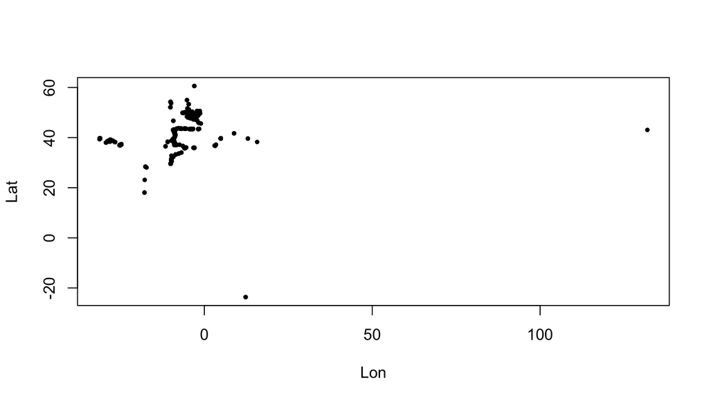

```r
records <- rbind(recordsGbif, recordsObis)
# plot the records
plot(records[, c("Lon", "Lat")], col = "Black", pch = 19, cex = 0.5)
```

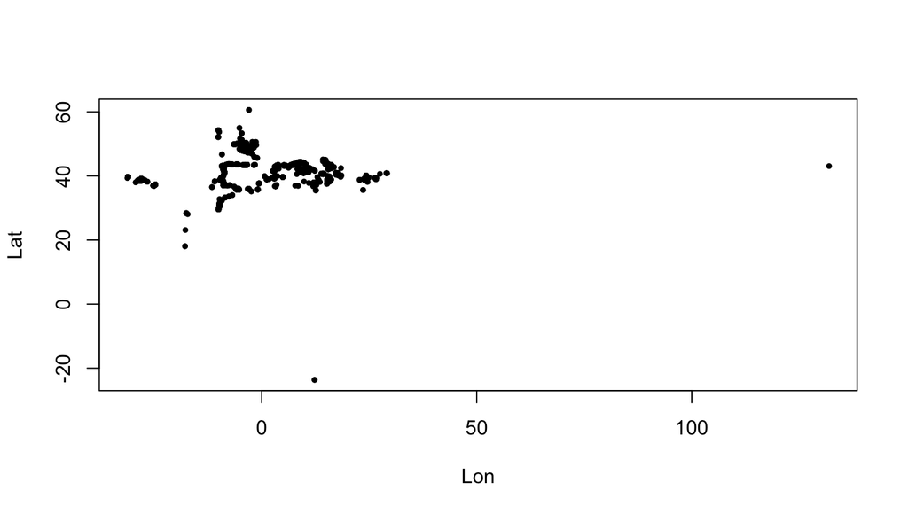

```r
recordsFile <- read.table("../Data/Text delimited/species_presence_records.csv", sep = ";", header = TRUE)
# combine the data.frames
library(plyr)
records <- rbind.fill(recordsFile, recordsGbif, recordsObis)
plot(records[, c("Lon", "Lat")], col = "Black", pch = 19, cex = 0.5)
```

## Data cleaning in R

### Remove NA coordinates

In species distribution modelling it is important to remove records with missing coordinates. This is because these records do not provide any information about the species distribution.

```r
# inspect the number of records with NA coordinates
sum(is.na(records$Lon) | is.na(records$Lat))
```

```
## [1] 315
```

```r
# remove NA coordinates
records <- records[!is.na(records$Lon) & !is.na(records$Lat), ]
# inspect the number of records
nrow(records)
```

```
## [1] 5551
```

### Remove duplicate coordinates

In species distribution models, duplicate coordinates are not useful. A species recorded at the same location multiple times does not add any new information to the model, and redundant information can introduce bias in the model. Therefore, it is important to remove duplicate coordinates from the dataset.

```r
# inspect the number of duplicated records
sum(duplicated(records))
```

```
## [1] 1882
```

```r
# remove duplicate coordinates
records <- records[!duplicated(records), ]
# inspect the number of records
nrow(records)
```

```
## [1] 3669
```

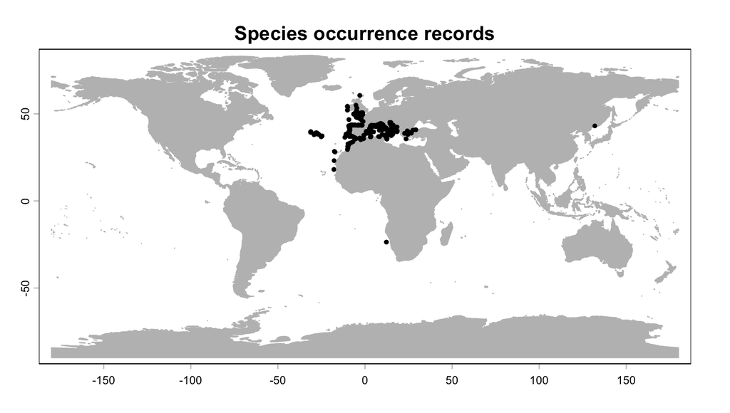

```r
# transform data.frame into a spatial object
records <- vect(records, geom = c("Lon", "Lat"), crs = "EPSG:4326")
# plot the landmass and the records
plot(landmass, main = "Species occurrence records", col = "Gray", border = "Gray", axes = TRUE)
plot(records, col = "Black", pch = 19, cex = 0.5, add = TRUE)
```

### Remove records on land

Marine species distribution models require the removal of records on land. This is because these records do not provide any information about the species distribution in the marine environment.

```r
nrow(records)
```

```
## [1] 3669
```

```r
# erase the records on land
records <- erase(records, landmass)
nrow(records)
```

```
## [1] 3025
```

### Remove records outside the known geographic distributions

In species distribution models, it is important to remove the records that are outside the known distribution of species. Import or generate (i.e., to draw) vector data - a polygon - depicting the global distribution of the species of interest.

```r
# Load necessary libraries
library(leaflet)
library(mapedit)

# create a base leaflet map
baseMap <- leaflet()
baseMap <- addTiles(baseMap)

# drawing vector polygon in the Viewer pane
myRegion <- drawFeatures(baseMap)
```

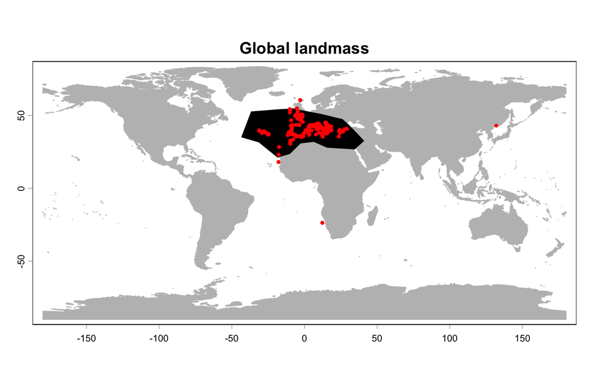

```r
# inspect the generated polygon depicting the distribution of the species
plot(landmass, main = "Global landmass", col = "gray", border = "gray", axes = TRUE)
plot(myRegion, border = "black", col = "black", add = TRUE)
plot(records, col = "red", pch = 19, cex = 0.5, add = TRUE)
```

Intersect the polygon with the occurrence records to exclude those outside the known distribution of the species.

```r
# Load necessary libraries
library(terra)
# transform the sf object to a terra object
myRegion <- vect(myRegion)
# intersect the records with the region
records <- intersect(records, myRegion)
# inspect the class of the object
class(records)
```

```
## [1] "SpatVector"
## attr(,"package")
## [1] "terra"
```

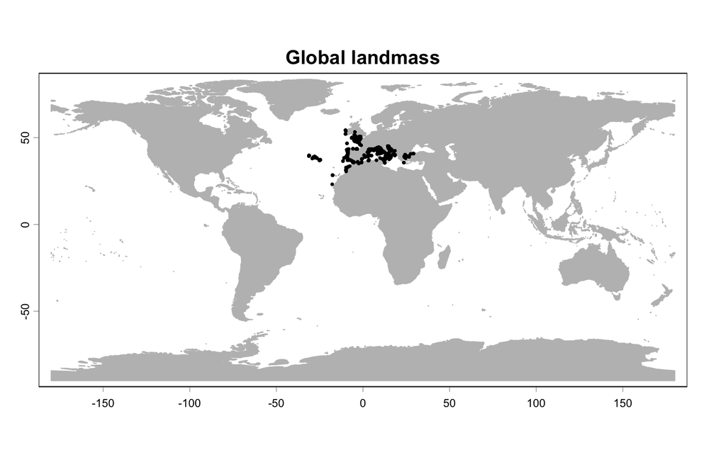

```r
# plot the distribution of the species without records outside the known distribution
plot(landmass, main = "Global landmass", col = "gray", border = "gray", axes = TRUE)
plot(records, color = "black", pch = 16, cex = 0.5, add = TRUE)
```

### Remove records outside the known vertical distributions

Import a bathymetry layer and remove records outside the known vertical distribution of the species.

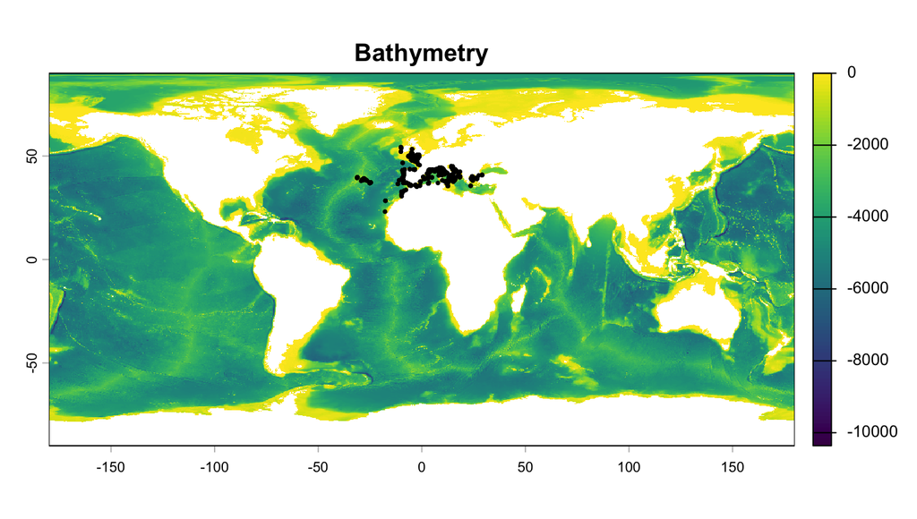

```r
# import bathymetry layer
bathymetry <- rast("../Data/Raster data/Bathymetry.tif")
# plot the bathymetry layer and the records of occurrence
plot(bathymetry, main = "Bathymetry", axes = TRUE)
plot(records, color = "black", pch = 16, cex = 0.5, add = TRUE)
```

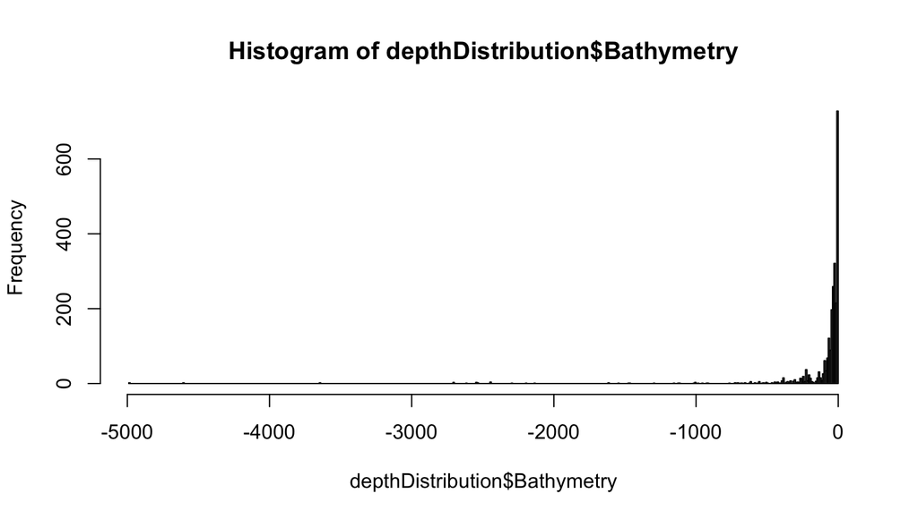

```r
# extract the values of the bathymetry based on the records
depthDistribution <- extract(bathymetry, records)
# plot the distribution of the depth records
hist(depthDistribution$Bathymetry, breaks = 500)
```

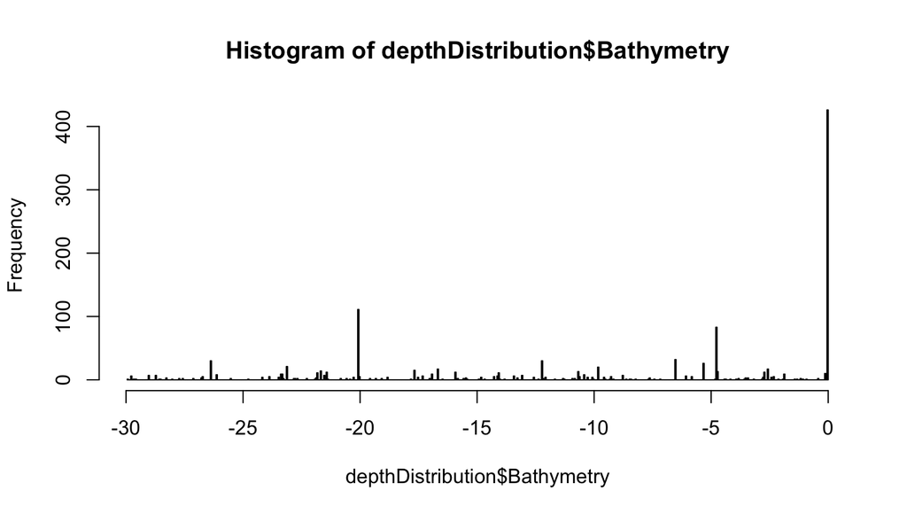

```r
# extract the depth values of the records
records <- records[depthDistribution$Bathymetry > -30, ]
# extract the depth values of the records
depthDistribution <- extract(bathymetry, records)
# plot the distribution of the depth records
hist(depthDistribution$Bathymetry, breaks = 500)
```

**Final spatial dataset** of records of occurrence of the species of interest **without NA coordinates**, **duplicate coordinates**, and **records outside the known geographic and vertical distribution**.

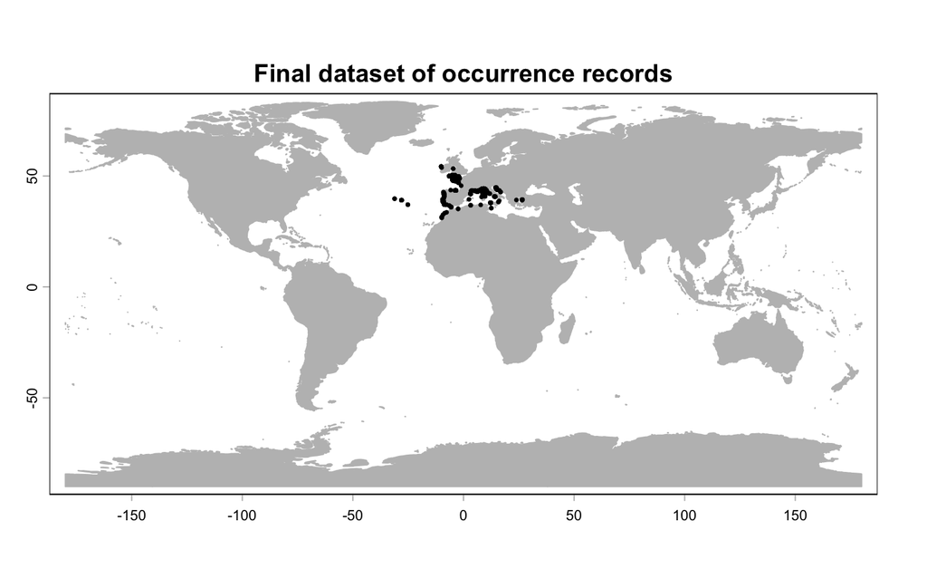

```r
# plot the final records
plot(landmass, main = "Final dataset of occurrence records", col = "gray", border = "gray", axes = TRUE)
plot(records, color = "black", pch = 16, cex = 0.5, add = TRUE)
```

### Challenge 3.2

The objective of this challenge is to **clean records** for a species of interest and produce a **plot**. A **recipe is provided**.

**Packages, data and functions to accomplish the challenge:**

**Files to use**  
"species_occurrence_records.csv"  
"landmass.shp"  
**Functions to use**  
library  
read.table  
getExternalDataGbif / getExternalDataObis  
rbind  
extract  
duplicated  
is.na  
vect  
leaflet  
addTiles  
drawFeatures  
intersect  
plot